# Information Content of Sports Games

Son Phan

## Initial Bradley-Terry Model

$$\begin{equation}
\ln\left( \frac{\pi_{i,j}}{1 - \pi_{i,j}} \right) = \theta_i - \theta_j + \alpha
\end{equation}$$

```r
# Filter down to one season and make sure factors for each team are consistent
nba_11 <- nba %>%
  filter(season == "2011") %>%
  mutate(
    home = factor(home),
    away = factor(away)
    )

# Create design matrix with no extra features
btm_matrix <- nba_11 %>%
  match_design_matrix(mov = FALSE)

# Fit glm without intercept
btm <- glm(formula = Y ~ . - 1, family = binomial(), data = btm_matrix)
summary(btm)
```

```
##
## Call:
## glm(formula = Y ~ . - 1, family = binomial(), data = btm_matrix)
##
## Deviance Residuals:
##     Min       1Q   Median       3Q      Max
## -2.3646  -0.9982   0.5264   0.8740   1.9976
##
## Coefficients:
##                              Estimate Std. Error z value Pr(>|z|)
## `teamBoston Celtics`          0.70886    0.34624   2.047 0.040627 *
## `teamCharlotte Bobcats`      -0.54306    0.33666  -1.613 0.106725
## `teamChicago Bulls`           1.08767    0.35983   3.023 0.002505 **
## `teamCleveland Cavaliers`    -1.49859    0.36422  -4.114 3.88e-05 ***
## `teamDallas Mavericks`        0.90274    0.35115   2.571 0.010147 *
## `teamDenver Nuggets`          0.46482    0.34235   1.358 0.174549
## `teamDetroit Pistons`        -0.79542    0.34084  -2.334 0.019611 *
## `teamGolden State Warriors`  -0.33039    0.34039  -0.971 0.331741
## `teamHouston Rockets`         0.06947    0.33962   0.205 0.837928
## `teamIndiana Pacers`         -0.38715    0.33445  -1.158 0.247046
## `teamLos Angeles Clippers`   -0.55504    0.34307  -1.618 0.105695
## `teamLos Angeles Lakers`      0.87126    0.35179   2.477 0.013262 *
## `teamMemphis Grizzlies`       0.24616    0.34033   0.723 0.469502
## `teamMiami Heat`              0.82899    0.34860   2.378 0.017405 *
## `teamMilwaukee Bucks`        -0.48879    0.33583  -1.455 0.145533
## `teamMinnesota Timberwolves` -1.52523    0.37569  -4.060 4.91e-05 ***
## `teamNew Jersey Nets`        -1.15586    0.34960  -3.306 0.000946 ***
## `teamNew Orleans Hornets`     0.26960    0.33961   0.794 0.427282
## `teamNew York Knicks`        -0.09867    0.33323  -0.296 0.767145
## `teamOklahoma City Thunder`   0.74118    0.34836   2.128 0.033367 *
## `teamOrlando Magic`           0.47759    0.33951   1.407 0.159511
## `teamPhiladelphia 76ers`     -0.18499    0.33432  -0.553 0.580036
## `teamPhoenix Suns`           -0.06579    0.33913  -0.194 0.846188
## `teamPortland Trail Blazers`  0.37810    0.34118   1.108 0.267770
## `teamSacramento Kings`       -1.02870    0.35326  -2.912 0.003591 **
## `teamSan Antonio Spurs`       1.16854    0.36026   3.244 0.001180 **
## `teamToronto Raptors`        -1.29555    0.35649  -3.634 0.000279 ***
## `teamUtah Jazz`              -0.14425    0.33891  -0.426 0.670381
## `teamWashington Wizards`     -1.21417    0.35276  -3.442 0.000578 ***
## hfa                           0.53427    0.06687   7.990 1.35e-15 ***
## ---
## Signif. codes:  0 '***' 0.001 '**' 0.01 '*' 0.05 '.' 0.1 ' ' 1
##
## (Dispersion parameter for binomial family taken to be 1)
##
##     Null deviance: 1705.1  on 1230  degrees of freedom
## Residual deviance: 1379.2  on 1200  degrees of freedom
## AIC: 1439.2
##
## Number of Fisher Scoring iterations: 4
```

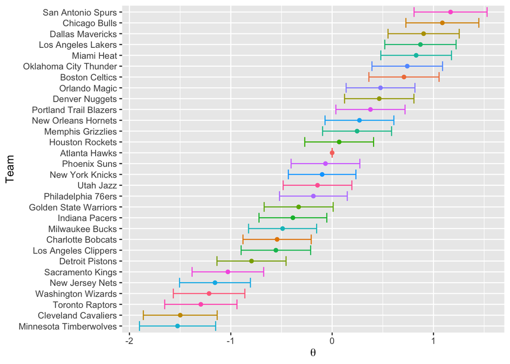

## Days Since Last Game

I add another variable within the Bradley-Terry model to measure the effect of how much down time teams have in between their matches. The variable **home_days_advantage** aims to measure the effect each day of rest a team has over their opponent has on their winning odds. This is shown in (2) with $\delta_{i}$ and $\delta_{j}$ representing the days since $i$ and $j$ played their last game respectively and $\beta$ being the effect parameter.

$$\begin{equation}
\ln\left( \frac{\pi_{i,j}}{1 - \pi_{i,j}} \right) = \theta_i - \theta_j + \alpha + \delta(d_{i} - d_{j})
\end{equation}$$

```r
# Create design matrix with home_days_advantage as an extra feature
btm_days_matrix <- nba_11 %>%
  mutate(home_days_advantage = home_days_since_last_game - away_days_since_last_game) %>%
  match_design_matrix(mov = FALSE, home_days_advantage)

btm_days <- glm(formula = Y ~ . - 1, family = "binomial", data = btm_days_matrix)
summary(btm_days)
```

```
##
## Call:
## glm(formula = Y ~ . - 1, family = "binomial", data = btm_days_matrix)
##
## Deviance Residuals:
##     Min       1Q   Median       3Q      Max
## -2.3735  -0.9888   0.5316   0.8662   2.0001
##
## Coefficients:
##                              Estimate Std. Error z value Pr(>|z|)
## `teamBoston Celtics`          0.71636    0.34646   2.068 0.038674 *
## `teamCharlotte Bobcats`      -0.53093    0.33659  -1.577 0.114705
## `teamChicago Bulls`           1.09797    0.36006   3.049 0.002293 **
## `teamCleveland Cavaliers`    -1.48616    0.36462  -4.076 4.58e-05 ***
## `teamDallas Mavericks`        0.90193    0.35105   2.569 0.010192 *
## `teamDenver Nuggets`          0.46859    0.34237   1.369 0.171106
## `teamDetroit Pistons`        -0.79227    0.34056  -2.326 0.019997 *
## `teamGolden State Warriors`  -0.33142    0.34043  -0.974 0.330298
## `teamHouston Rockets`         0.06658    0.33969   0.196 0.844600
## `teamIndiana Pacers`         -0.38639    0.33464  -1.155 0.248242
## `teamLos Angeles Clippers`   -0.55786    0.34290  -1.627 0.103763
## `teamLos Angeles Lakers`      0.86316    0.35199   2.452 0.014198 *
## `teamMemphis Grizzlies`       0.24505    0.34020   0.720 0.471328
## `teamMiami Heat`              0.83066    0.34864   2.383 0.017191 *
## `teamMilwaukee Bucks`        -0.48443    0.33571  -1.443 0.149016
## `teamMinnesota Timberwolves` -1.52221    0.37590  -4.050 5.13e-05 ***
## `teamNew Jersey Nets`        -1.15159    0.35000  -3.290 0.001001 **
## `teamNew Orleans Hornets`     0.27149    0.33934   0.800 0.423689
## `teamNew York Knicks`        -0.09927    0.33315  -0.298 0.765717
## `teamOklahoma City Thunder`   0.74717    0.34840   2.145 0.031984 *
## `teamOrlando Magic`           0.47895    0.33918   1.412 0.157928
## `teamPhiladelphia 76ers`     -0.18252    0.33441  -0.546 0.585199
## `teamPhoenix Suns`           -0.05967    0.33915  -0.176 0.860328
## `teamPortland Trail Blazers`  0.38550    0.34132   1.129 0.258721
## `teamSacramento Kings`       -1.02941    0.35297  -2.916 0.003541 **
## `teamSan Antonio Spurs`       1.16986    0.36057   3.244 0.001177 **
## `teamToronto Raptors`        -1.30017    0.35646  -3.647 0.000265 ***
## `teamUtah Jazz`              -0.13928    0.33919  -0.411 0.681340
## `teamWashington Wizards`     -1.21739    0.35263  -3.452 0.000556 ***
## hfa                           0.55299    0.06985   7.916 2.45e-15 ***
## home_days_advantage          -0.05276    0.05534  -0.953 0.340368
## ---
## Signif. codes:  0 '***' 0.001 '**' 0.01 '*' 0.05 '.' 0.1 ' ' 1
##
## (Dispersion parameter for binomial family taken to be 1)
##
##     Null deviance: 1705.1  on 1230  degrees of freedom
## Residual deviance: 1378.3  on 1199  degrees of freedom
## AIC: 1440.3
##
## Number of Fisher Scoring iterations: 4
```

My prior going into fitting this model is that coefficient for **home_days_advantage**, $\delta$ would likely be very insignificant. Just by my thinking, the amount of days in between matches might have a more complex relationship with winning odds and is likely not linear. For instance, a long time not playing may give teams an opportunity to rest but also can make them deconditioned from intense competition, on the flipside, a team can have a lot of momentum playing a lot frequently but can result in injuries and ‘burnout’.

We end up seeing a pretty small coefficient as well as a low absolute z score and higher p value. Most of the strength parameters are not really affected by the inclusion of this predictor, with the change across $\theta$’s being below the order of $0.01$. In addition to looking at a deeper number of lagged games, testing this across seasons as well as with the measuring information content through forecasting will be a good step forward.

However, this **home_days_advantage** on the full sample of games across seasons is significant and positive

```r
# Create design matrix with home_days_advantage as an extra feature
btm_days_full_matrix <- nba %>%
  mutate(home_days_advantage = home_days_since_last_game - away_days_since_last_game) %>%
  match_design_matrix(mov = FALSE, home_days_advantage)

btm_days_full <- glm(formula = Y ~ . - 1, family = "binomial", data = btm_days_full_matrix)
summary(btm_days_full)
```

```
##
## Call:
## glm(formula = Y ~ . - 1, family = "binomial", data = btm_days_full_matrix)
##
## Deviance Residuals:
##    Min      1Q  Median      3Q     Max
## -2.055  -1.269   0.848   1.016   1.673
##
## Coefficients:
##                                          Estimate Std. Error z value Pr(>|z|)
## `teamBoston Celtics`                     0.364596   0.069926   5.214 1.85e-07
## `teamBrooklyn Nets`                     -0.102870   0.099466  -1.034 0.301034
## `teamCharlotte Bobcats`                 -0.378902   0.089239  -4.246 2.18e-05
## `teamCharlotte Hornets`                  0.225924   0.091204   2.477 0.013245
## `teamChicago Bulls`                      0.006274   0.069846   0.090 0.928424
## `teamCleveland Cavaliers`                0.125988   0.069796   1.805 0.071063
## `teamDallas Mavericks`                   0.666256   0.071616   9.303  < 2e-16
## `teamDenver Nuggets`                     0.336824   0.071023   4.742 2.11e-06
## `teamDetroit Pistons`                    0.252989   0.069745   3.627 0.000286
## `teamGolden State Warriors`              0.308827   0.071024   4.348 1.37e-05
## `teamHouston Rockets`                    0.592245   0.071413   8.293  < 2e-16
## `teamIndiana Pacers`                     0.375852   0.069906   5.376 7.59e-08
## `teamLos Angeles Clippers`               0.149683   0.071016   2.108 0.035053
## `teamLos Angeles Lakers`                 0.507157   0.071236   7.119 1.08e-12
## `teamMemphis Grizzlies`                  0.191317   0.073567   2.601 0.009306
## `teamMiami Heat`                         0.427589   0.069923   6.115 9.65e-10
## `teamMilwaukee Bucks`                    0.079492   0.069810   1.139 0.254831
## `teamMinnesota Timberwolves`             0.014004   0.071226   0.197 0.844126
## `teamNew Jersey Nets`                   -0.071874   0.078979  -0.910 0.362798
## `teamNew Orleans Hornets`                0.169663   0.091459   1.855 0.063585
## `teamNew Orleans Pelicans`               0.128507   0.105862   1.214 0.224779
## `teamNew Orleans/Oklahoma City Hornets`  0.149098   0.168986   0.882 0.377610
## `teamNew York Knicks`                   -0.135625   0.070190  -1.932 0.053327
## `teamOklahoma City Thunder`              0.749493   0.086729   8.642  < 2e-16
## `teamOrlando Magic`                      0.091928   0.069716   1.319 0.187299
## `teamPhiladelphia 76ers`                 0.032868   0.069904   0.470 0.638218
## `teamPhoenix Suns`                       0.308749   0.070975   4.350 1.36e-05
## `teamPortland Trail Blazers`             0.469820   0.071142   6.604 4.00e-11
## `teamSacramento Kings`                   0.129281   0.071062   1.819 0.068873
## `teamSan Antonio Spurs`                  1.152358   0.074210  15.528  < 2e-16
```

[output cut: 40 more lines]

```
## `teamUtah Jazz`                         ***
## `teamVancouver Grizzlies`               ***
## `teamWashington Wizards`                .
## hfa                                     ***
## home_days_advantage                     ***
## ---
## Signif. codes:  0 '***' 0.001 '**' 0.01 '*' 0.05 '.' 0.1 ' ' 1
##
## (Dispersion parameter for binomial family taken to be 1)
##
##     Null deviance: 34490  on 24879  degrees of freedom
## Residual deviance: 32586  on 24842  degrees of freedom
## AIC: 32660
##
## Number of Fisher Scoring iterations: 4
```

I redo this model letting the coefficient for `home_days_since_last_game` and `away_days_since_last_game` be different and manually running the regression in glm. This equation is expressed below.

$$\begin{equation}
\ln\left( \frac{\pi_{i,j}}{1 - \pi_{i,j}} \right) = \theta_i - \theta_j + \alpha + \delta_h d_{i} - \delta_a d_{j}
\end{equation}$$

```r
# Create design matrix with home_days and away_days as extra features
btm_days_sep_matrix <- nba_11 %>%
  match_design_matrix(mov = FALSE, home_days_since_last_game, away_days_since_last_game)

# Fit with -1 to remove intercept factor in estimation
btm_days_sep <- glm(formula = Y ~ . - 1, family = "binomial", data = btm_days_sep_matrix)
summary(btm_days_sep)
```

```
##
## Call:
## glm(formula = Y ~ . - 1, family = "binomial", data = btm_days_sep_matrix)
##
## Deviance Residuals:
##     Min       1Q   Median       3Q      Max
## -2.3837  -0.9940   0.5309   0.8678   2.0023
##
## Coefficients:
##                              Estimate Std. Error z value Pr(>|z|)
## `teamBoston Celtics`          0.72010    0.34682   2.076 0.037866 *
## `teamCharlotte Bobcats`      -0.52822    0.33669  -1.569 0.116681
## `teamChicago Bulls`           1.10030    0.36013   3.055 0.002248 **
## `teamCleveland Cavaliers`    -1.48073    0.36528  -4.054 5.04e-05 ***
## `teamDallas Mavericks`        0.90752    0.35173   2.580 0.009876 **
## `teamDenver Nuggets`          0.47524    0.34341   1.384 0.166396
## `teamDetroit Pistons`        -0.78872    0.34095  -2.313 0.020704 *
## `teamGolden State Warriors`  -0.32401    0.34172  -0.948 0.343042
## `teamHouston Rockets`         0.06967    0.33996   0.205 0.837625
## `teamIndiana Pacers`         -0.38097    0.33539  -1.136 0.256005
## `teamLos Angeles Clippers`   -0.55282    0.34347  -1.610 0.107505
## `teamLos Angeles Lakers`      0.87110    0.35333   2.465 0.013685 *
## `teamMemphis Grizzlies`       0.24780    0.34028   0.728 0.466477
## `teamMiami Heat`              0.83467    0.34900   2.392 0.016775 *
## `teamMilwaukee Bucks`        -0.48225    0.33580  -1.436 0.150972
## `teamMinnesota Timberwolves` -1.52141    0.37591  -4.047 5.18e-05 ***
## `teamNew Jersey Nets`        -1.14511    0.35092  -3.263 0.001102 **
## `teamNew Orleans Hornets`     0.27932    0.34072   0.820 0.412334
## `teamNew York Knicks`        -0.09106    0.33480  -0.272 0.785641
## `teamOklahoma City Thunder`   0.75481    0.34978   2.158 0.030929 *
## `teamOrlando Magic`           0.48577    0.34029   1.428 0.153432
## `teamPhiladelphia 76ers`     -0.17852    0.33473  -0.533 0.593807
## `teamPhoenix Suns`           -0.05486    0.33964  -0.162 0.871673
## `teamPortland Trail Blazers`  0.39290    0.34273   1.146 0.251644
## `teamSacramento Kings`       -1.02815    0.35291  -2.913 0.003576 **
## `teamSan Antonio Spurs`       1.17493    0.36113   3.253 0.001140 **
## `teamToronto Raptors`        -1.29592    0.35679  -3.632 0.000281 ***
## `teamUtah Jazz`              -0.13650    0.33934  -0.402 0.687494
## `teamWashington Wizards`     -1.21354    0.35284  -3.439 0.000583 ***
## hfa                           0.59979    0.20297   2.955 0.003125 **
## home_days_since_last_game    -0.06309    0.06946  -0.908 0.363719
## away_days_since_last_game     0.04072    0.07386   0.551 0.581473
## ---
## Signif. codes:  0 '***' 0.001 '**' 0.01 '*' 0.05 '.' 0.1 ' ' 1
##
## (Dispersion parameter for binomial family taken to be 1)
##
##     Null deviance: 1705.1  on 1230  degrees of freedom
## Residual deviance: 1378.3  on 1198  degrees of freedom
## AIC: 1442.3
##
## Number of Fisher Scoring iterations: 4
```

It still remains that having more days out since last game for the home team reduces their chance of winning. On the flipside having more days out on the away team increase the home team’s chance of winning. All in all, the model spits out a negative effect on winning probability for increased days out.

Continuing onward, it is quite possible that there is a non-linear relationship between days out and winning odds, additionally the sample is centered about around 2 `days_since_last_game`. I want to test this first by fitting the same model as (2), having the number of days out be a factor variable. The equation is outlined below where 9 is the highest number of days out, $\delta_{i}$ is the effect of having a team be $i$ days out on the winning odds for the home team and $d_{h, i}$/$d_{a, i}$ is 1 or 0 whether the home/away team is $i$ days out or not.

$$\begin{equation}
\displaystyle \ln\left( \frac{\pi_{i,j}}{1 - \pi_{i,j}} \right) = \theta_i - \theta_j + \alpha + \sum_{i = 1}^{9}\delta_{i}d_{h, i} + \sum_{i = 1}^{9}\delta_{i}d_{a, i}
\end{equation}$$

```r
# Create factor variables for home & away with the same levels
all_days_values <- unique(union(nba_11$home_days_since_last_game, nba_11$away_days_since_last_game))
nba_days_fct <- nba %>%
  mutate(
    home_days_since_last_game = factor(x = home_days_since_last_game, levels = all_days_values),
    away_days_since_last_game = factor(x = away_days_since_last_game, levels = all_days_values)
  )

home_days_out <- nba_11 %>%
  mutate(
    days_out = fct_relevel(factor(x = home_days_since_last_game, levels = all_days_values), "1", "2", "3")) %>%
  model.matrix(~ days_out - 1, .) %>% .[, -1] # days_out1 factor as the 0 reference level

away_days_out <- nba_11 %>%
  mutate(
    days_out = fct_relevel(factor(x = away_days_since_last_game, levels = all_days_values), "1", "2", "3")) %>%
  model.matrix(~ days_out - 1, .) %>% .[, -1] # days_out1 factor as the 0 reference level

# Create design matrix and attach days_out factor matrix
btm_days_fct_matrix <- nba_11 %>%
  match_design_matrix(mov = FALSE) %>% cbind(home_days_out - away_days_out)

# Fit with -1 to remove intercept factor in estimation
btm_days_fct <- glm(formula = Y ~ . - 1, family = "binomial", data = btm_days_fct_matrix)
summary(btm_days_fct)
```

```
##
## Call:
## glm(formula = Y ~ . - 1, family = "binomial", data = btm_days_fct_matrix)
##
## Deviance Residuals:
##     Min       1Q   Median       3Q      Max
## -2.3711  -0.9845   0.5258   0.8755   2.1444
##
## Coefficients:
##                                Estimate Std. Error z value Pr(>|z|)
## `teamBoston Celtics`           0.721805   0.346989   2.080 0.037508 *
## `teamCharlotte Bobcats`       -0.548884   0.337282  -1.627 0.103657
## `teamChicago Bulls`            1.111792   0.360957   3.080 0.002069 **
## `teamCleveland Cavaliers`     -1.497482   0.365988  -4.092 4.28e-05 ***
## `teamDallas Mavericks`         0.898330   0.354430   2.535 0.011258 *
## `teamDenver Nuggets`           0.412221   0.344649   1.196 0.231673
## `teamDetroit Pistons`         -0.804669   0.340858  -2.361 0.018240 *
## `teamGolden State Warriors`   -0.347812   0.341080  -1.020 0.307853
## `teamHouston Rockets`          0.036644   0.341486   0.107 0.914545
## `teamIndiana Pacers`          -0.399304   0.335950  -1.189 0.234605
## `teamLos Angeles Clippers`    -0.577951   0.343516  -1.682 0.092480 .
## `teamLos Angeles Lakers`       0.834012   0.352881   2.363 0.018106 *
## `teamMemphis Grizzlies`        0.237767   0.341728   0.696 0.486567
## `teamMiami Heat`               0.798484   0.349475   2.285 0.022324 *
## `teamMilwaukee Bucks`         -0.501185   0.337011  -1.487 0.136976
## `teamMinnesota Timberwolves`  -1.530715   0.375906  -4.072 4.66e-05 ***
## `teamNew Jersey Nets`         -1.160289   0.350800  -3.308 0.000941 ***
## `teamNew Orleans Hornets`      0.228446   0.340556   0.671 0.502346
## `teamNew York Knicks`         -0.072953   0.333528  -0.219 0.826859
## `teamOklahoma City Thunder`    0.716225   0.350470   2.044 0.040992 *
## `teamOrlando Magic`            0.453409   0.340998   1.330 0.183633
## `teamPhiladelphia 76ers`      -0.162644   0.335396  -0.485 0.627725
## `teamPhoenix Suns`            -0.116668   0.340572  -0.343 0.731926
## `teamPortland Trail Blazers`   0.391436   0.344822   1.135 0.256298
## `teamSacramento Kings`        -1.077499   0.355215  -3.033 0.002418 **
## `teamSan Antonio Spurs`        1.169463   0.365382   3.201 0.001371 **
## `teamToronto Raptors`         -1.319589   0.357314  -3.693 0.000222 ***
## `teamUtah Jazz`               -0.181383   0.341534  -0.531 0.595361
## `teamWashington Wizards`      -1.272765   0.353616  -3.599 0.000319 ***
## hfa                            0.531220   0.071332   7.447 9.54e-14 ***
## days_out2                      0.255353   0.134290   1.902 0.057236 .
## days_out3                     -0.137965   0.168407  -0.819 0.412652
## days_out4                      0.008225   0.237663   0.035 0.972392
## days_out5                      0.227366   0.584730   0.389 0.697395
## days_out6                     -0.286626   0.733736  -0.391 0.696065
## days_out7                     -0.762422   0.790947  -0.964 0.335078
## days_out9                     -9.449737 324.743957  -0.029 0.976786
## ---
## Signif. codes:  0 '***' 0.001 '**' 0.01 '*' 0.05 '.' 0.1 ' ' 1
##
## (Dispersion parameter for binomial family taken to be 1)
##
##     Null deviance: 1705.1  on 1230  degrees of freedom
## Residual deviance: 1369.1  on 1193  degrees of freedom
## AIC: 1443.1
##
## Number of Fisher Scoring iterations: 11
```

It’s a pretty non-linear trend. It seems like the high days out really messes with winning odds so that may be why it’s trending negative on the continuous models (2)/(3). I’ll look into the decision tree models. I want to try on the entire data set to see if this rings true since the only day_out9 is for an away team so that may be skewing things heavily. Also, I use days_out0 as the first game of the season, should think about how we think about the first day of the season in the data.

```r
all_days_values <- unique(union(nba$home_days_since_last_game, nba$away_days_since_last_game))
nba_days_fct <- nba %>%
  mutate(
    home_days_since_last_game = factor(x = home_days_since_last_game, levels = all_days_values),
    away_days_since_last_game = factor(x = away_days_since_last_game, levels = all_days_values)
  )

home_days_out_full <- nba %>%
  mutate(
    days_out = fct_relevel(factor(x = home_days_since_last_game, levels = all_days_values), "1", "2", "3")) %>%
  model.matrix(~ days_out - 1, .) %>% .[, -1] # days_out1 factor as the 0 reference level

away_days_out_full <- nba %>%
  mutate(
    days_out = fct_relevel(factor(x = away_days_since_last_game, levels = all_days_values), "1", "2", "3")) %>%
  model.matrix(~ days_out - 1, .) %>% .[, -1] # days_out1 factor as the 0 reference level

btm_days_fct_matrix_full <- nba %>%
  match_design_matrix(mov = FALSE) %>% cbind(home_days_out_full - away_days_out_full)

# Fit with -1 to remove intercept factor in estimation
btm_days_fct_full <- glm(formula = Y ~ . - 1, family = "binomial", data = btm_days_fct_matrix_full)
summary(btm_days_fct_full)
```

```
##
## Call:
## glm(formula = Y ~ . - 1, family = "binomial", data = btm_days_fct_matrix_full)
##
## Deviance Residuals:
##     Min       1Q   Median       3Q      Max
## -2.2014  -1.2651   0.8414   1.0139   1.6902
##
## Coefficients:
##                                          Estimate Std. Error z value Pr(>|z|)
## `teamBoston Celtics`                     0.363638   0.069988   5.196 2.04e-07
## `teamBrooklyn Nets`                     -0.101215   0.099645  -1.016 0.309746
## `teamCharlotte Bobcats`                 -0.378445   0.089313  -4.237 2.26e-05
## `teamCharlotte Hornets`                  0.226661   0.091314   2.482 0.013057
## `teamChicago Bulls`                      0.005708   0.069927   0.082 0.934943
## `teamCleveland Cavaliers`                0.126323   0.069859   1.808 0.070565
## `teamDallas Mavericks`                   0.661171   0.071722   9.218  < 2e-16
## `teamDenver Nuggets`                     0.331796   0.071134   4.664 3.10e-06
## `teamDetroit Pistons`                    0.253926   0.069801   3.638 0.000275
## `teamGolden State Warriors`              0.307385   0.071129   4.322 1.55e-05
## `teamHouston Rockets`                    0.590749   0.071500   8.262  < 2e-16
## `teamIndiana Pacers`                     0.381595   0.069978   5.453 4.95e-08
## `teamLos Angeles Clippers`               0.146123   0.071079   2.056 0.039804
## `teamLos Angeles Lakers`                 0.508817   0.071331   7.133 9.81e-13
## `teamMemphis Grizzlies`                  0.194323   0.073641   2.639 0.008320
## `teamMiami Heat`                         0.430768   0.070017   6.152 7.64e-10
## `teamMilwaukee Bucks`                    0.078048   0.069883   1.117 0.264068
## `teamMinnesota Timberwolves`             0.011585   0.071304   0.162 0.870937
## `teamNew Jersey Nets`                   -0.072949   0.079067  -0.923 0.356202
## `teamNew Orleans Hornets`                0.165905   0.091552   1.812 0.069962
## `teamNew Orleans Pelicans`               0.129680   0.105912   1.224 0.220797
## `teamNew Orleans/Oklahoma City Hornets`  0.134146   0.169264   0.793 0.428055
## `teamNew York Knicks`                   -0.135822   0.070253  -1.933 0.053195
## `teamOklahoma City Thunder`              0.745328   0.086812   8.586  < 2e-16
## `teamOrlando Magic`                      0.090387   0.069771   1.295 0.195157
## `teamPhiladelphia 76ers`                 0.034123   0.069969   0.488 0.625772
## `teamPhoenix Suns`                       0.305377   0.071076   4.296 1.74e-05
## `teamPortland Trail Blazers`             0.465690   0.071240   6.537 6.28e-11
## `teamSacramento Kings`                   0.128417   0.071132   1.805 0.071022
## `teamSan Antonio Spurs`                  1.150689   0.074309  15.485  < 2e-16
```

[output cut: 58 more lines]

```
## days_out7
## days_out8
## days_out9
## days_out11
## days_out10                              *
## ---
## Signif. codes:  0 '***' 0.001 '**' 0.01 '*' 0.05 '.' 0.1 ' ' 1
##
## (Dispersion parameter for binomial family taken to be 1)
##
##     Null deviance: 34490  on 24879  degrees of freedom
## Residual deviance: 32532  on 24833  degrees of freedom
## AIC: 32624
##
## Number of Fisher Scoring iterations: 4
```

Interesting… It seems like the sweet spot in the whole set is around 2/3 days but that is also where the distribution of days_out is concentrated. This confirms pretty heavily our non-linear hypothesis though I think. Also, just an FYI, the days_out10 occurs only in the away_days_since_last_game column so there’s likely a skew there.

## Away Distance Traveled

Another feature I looked at was the distance that the away team had to travel before a particular match. This is similar to the previous theory that players may get burned out and possibly more burned out by having to travel more. The model is outlined below with $d_{j,i}$ being the distance between team $j$ and team $i$’s location. I use approximate locations based on cities rather than exact stadium locations.

$$\begin{equation}
\ln\left( \frac{\pi_{i,j}}{1 - \pi_{i,j}} \right) = \theta_i - \theta_j + \alpha + \delta d_{j,i}
\end{equation}$$

```r
# Create design matrix with home_days_advantage as an extra feature
btm_dist_matrix <- nba_11 %>%
  match_design_matrix(mov = FALSE, away_distance_traveled)

btm_dist <- glm(formula = Y ~ . - 1, family = "binomial", data = btm_dist_matrix)
summary(btm_dist)
```

```
##
## Call:
## glm(formula = Y ~ . - 1, family = "binomial", data = btm_dist_matrix)
##
## Deviance Residuals:
##     Min       1Q   Median       3Q      Max
## -2.3591  -0.9912   0.5347   0.8716   2.0468
##
## Coefficients:
##                                Estimate Std. Error z value Pr(>|z|)
## `teamBoston Celtics`          7.110e-01  3.461e-01   2.054 0.039962 *
## `teamCharlotte Bobcats`      -5.450e-01  3.376e-01  -1.614 0.106440
## `teamChicago Bulls`           1.096e+00  3.604e-01   3.042 0.002352 **
## `teamCleveland Cavaliers`    -1.506e+00  3.654e-01  -4.120 3.79e-05 ***
## `teamDallas Mavericks`        9.034e-01  3.520e-01   2.567 0.010268 *
## `teamDenver Nuggets`          4.624e-01  3.428e-01   1.349 0.177350
## `teamDetroit Pistons`        -7.979e-01  3.419e-01  -2.334 0.019603 *
## `teamGolden State Warriors`  -3.310e-01  3.399e-01  -0.974 0.330141
## `teamHouston Rockets`         6.092e-02  3.401e-01   0.179 0.857856
## `teamIndiana Pacers`         -3.881e-01  3.354e-01  -1.157 0.247319
## `teamLos Angeles Clippers`   -5.578e-01  3.428e-01  -1.627 0.103694
## `teamLos Angeles Lakers`      8.667e-01  3.515e-01   2.466 0.013657 *
## `teamMemphis Grizzlies`       2.455e-01  3.410e-01   0.720 0.471597
## `teamMiami Heat`              8.238e-01  3.487e-01   2.362 0.018164 *
## `teamMilwaukee Bucks`        -4.895e-01  3.366e-01  -1.454 0.145898
## `teamMinnesota Timberwolves` -1.525e+00  3.759e-01  -4.057 4.98e-05 ***
## `teamNew Jersey Nets`        -1.157e+00  3.504e-01  -3.302 0.000961 ***
## `teamNew Orleans Hornets`     2.642e-01  3.401e-01   0.777 0.437223
## `teamNew York Knicks`        -9.517e-02  3.337e-01  -0.285 0.775478
## `teamOklahoma City Thunder`   7.404e-01  3.491e-01   2.121 0.033938 *
## `teamOrlando Magic`           4.758e-01  3.400e-01   1.400 0.161652
## `teamPhiladelphia 76ers`     -1.830e-01  3.350e-01  -0.546 0.584964
## `teamPhoenix Suns`           -6.814e-02  3.391e-01  -0.201 0.840755
## `teamPortland Trail Blazers`  3.737e-01  3.404e-01   1.098 0.272233
## `teamSacramento Kings`       -1.028e+00  3.529e-01  -2.912 0.003591 **
## `teamSan Antonio Spurs`       1.166e+00  3.608e-01   3.231 0.001234 **
## `teamToronto Raptors`        -1.301e+00  3.576e-01  -3.637 0.000275 ***
## `teamUtah Jazz`              -1.479e-01  3.390e-01  -0.436 0.662585
## `teamWashington Wizards`     -1.219e+00  3.538e-01  -3.444 0.000573 ***
## hfa                           6.652e-01  1.255e-01   5.301 1.15e-07 ***
## away_distance_traveled       -7.773e-05  6.267e-05  -1.240 0.214867
## ---
## Signif. codes:  0 '***' 0.001 '**' 0.01 '*' 0.05 '.' 0.1 ' ' 1
##
## (Dispersion parameter for binomial family taken to be 1)
##
##     Null deviance: 1705.1  on 1230  degrees of freedom
## Residual deviance: 1377.7  on 1199  degrees of freedom
## AIC: 1439.7
##
## Number of Fisher Scoring iterations: 4
```

I try this one more time for the full sample of all games

```r
# Create design matrix with home_days_advantage as an extra feature
btm_dist_matrix <- nba %>%
  match_design_matrix(mov = FALSE, away_distance_traveled)

btm_dist <- glm(formula = Y ~ . - 1, family = "binomial", data = btm_dist_matrix)
summary(btm_dist)
```

```
##
## Call:
## glm(formula = Y ~ . - 1, family = "binomial", data = btm_dist_matrix)
##
## Deviance Residuals:
##     Min       1Q   Median       3Q      Max
## -2.0337  -1.2763   0.8542   1.0171   1.6751
##
## Coefficients:
##                                           Estimate Std. Error z value Pr(>|z|)
## `teamBoston Celtics`                     3.619e-01  6.991e-02   5.177 2.25e-07
## `teamBrooklyn Nets`                     -1.066e-01  9.950e-02  -1.071 0.284164
## `teamCharlotte Bobcats`                 -3.766e-01  8.926e-02  -4.219 2.46e-05
## `teamCharlotte Hornets`                  2.284e-01  9.124e-02   2.503 0.012311
## `teamChicago Bulls`                      6.880e-03  6.987e-02   0.098 0.921561
## `teamCleveland Cavaliers`                1.248e-01  6.980e-02   1.788 0.073770
## `teamDallas Mavericks`                   6.602e-01  7.159e-02   9.221  < 2e-16
## `teamDenver Nuggets`                     3.331e-01  7.101e-02   4.691 2.72e-06
## `teamDetroit Pistons`                    2.516e-01  6.976e-02   3.606 0.000311
## `teamGolden State Warriors`              3.069e-01  7.094e-02   4.326 1.52e-05
## `teamHouston Rockets`                    5.885e-01  7.139e-02   8.243  < 2e-16
## `teamIndiana Pacers`                     3.753e-01  6.992e-02   5.367 7.99e-08
## `teamLos Angeles Clippers`               1.449e-01  7.096e-02   2.043 0.041099
## `teamLos Angeles Lakers`                 4.985e-01  7.117e-02   7.004 2.49e-12
## `teamMemphis Grizzlies`                  1.881e-01  7.354e-02   2.558 0.010519
## `teamMiami Heat`                         4.237e-01  6.988e-02   6.063 1.33e-09
## `teamMilwaukee Bucks`                    8.137e-02  6.982e-02   1.166 0.243815
## `teamMinnesota Timberwolves`             1.321e-02  7.122e-02   0.185 0.852872
## `teamNew Jersey Nets`                   -7.292e-02  7.899e-02  -0.923 0.355944
## `teamNew Orleans Hornets`                1.693e-01  9.138e-02   1.853 0.063928
## `teamNew Orleans Pelicans`               1.243e-01  1.058e-01   1.175 0.239885
## `teamNew Orleans/Oklahoma City Hornets`  1.481e-01  1.688e-01   0.877 0.380322
## `teamNew York Knicks`                   -1.391e-01  7.020e-02  -1.981 0.047577
## `teamOklahoma City Thunder`              7.434e-01  8.673e-02   8.571  < 2e-16
## `teamOrlando Magic`                      9.309e-02  6.970e-02   1.336 0.181697
## `teamPhiladelphia 76ers`                 3.236e-02  6.990e-02   0.463 0.643428
## `teamPhoenix Suns`                       3.058e-01  7.094e-02   4.311 1.62e-05
## `teamPortland Trail Blazers`             4.656e-01  7.108e-02   6.551 5.72e-11
## `teamSacramento Kings`                   1.239e-01  7.101e-02   1.744 0.081087
## `teamSan Antonio Spurs`                  1.145e+00  7.416e-02  15.436  < 2e-16
```

[output cut: 40 more lines]

```
## `teamUtah Jazz`                         ***
## `teamVancouver Grizzlies`               ***
## `teamWashington Wizards`                .
## hfa                                     ***
## away_distance_traveled
## ---
## Signif. codes:  0 '***' 0.001 '**' 0.01 '*' 0.05 '.' 0.1 ' ' 1
##
## (Dispersion parameter for binomial family taken to be 1)
##
##     Null deviance: 34490  on 24879  degrees of freedom
## Residual deviance: 32613  on 24842  degrees of freedom
## AIC: 32687
##
## Number of Fisher Scoring iterations: 4
```

## Quantifying Information Content: Random Sample Games

This process is marked by a few steps outlined by Wolfson-Koopmeiners. In general we want to:

- Fit a rating model on several training sets with proportion *p* of total season games
- Calculate predicted probabilities, $\pi_{ij}$ for the results of each match in the remaining season’s games
- Simulate using the set of all $\pi$, the remaining season’s games and measure the accuracy
- Repeat for different *p* across different seasons and leagues

Next steps will be to evaluate this method for sequential games as well as directly compare it to Wolfson Koopmeiner’s information metric.

```r
#Sorry for the monster of a call, the gist is that I'm using a dataframe where some columns are also dataframes, using map makes things similar to apply functions to each dataframe element, futuremap is a parallel processing implementation of purrr's original map from the tidyverse

#Take a dataframe where each row is a training set and test set of a proportion
info_sets <- training_split_df(df = nba_11, prop = c(0.125,0.25, 0.375, 0.50, 0.625, 0.75, 0.875), n_sets = 100, mov = FALSE)

info_metrics <- info_sets %>%
  group_by(train_prop) %>%
  mutate(
    set_id = row_number(),
    btm = future_map(.x = train, .f = ~glm(formula = Y ~ . - 1, family = binomial(), data = .x)),
    pred_logit = future_map2(.x = test, .y = btm, .f = ~predict.glm(object = .y, newdata = .x)),
    pred_prob = future_map(.x = pred_logit, .f = sigmoid),
    # sim = future_map(.x = pred_prob, .f = ~ifelse(test = .x < 0.6 & .x > 0.4, yes = rbinom(n = length(.x), size = 1, prob = .x), no = (. > 0.5))),
    sim = future_map(.x = pred_prob, .f = ~rbinom(n = length(.x), size = 1, prob = .x)),
    naive_sim = future_map(.x = pred_prob, .f = ~(. > 0.5)),
    actual = future_map(.x = test, .f = ~pull(.data = .x, var = 'Y')),
    info_metric = unlist(future_map2(.x = sim, .y = actual, .f = ~pred_accuracy(sim = .x, actual = .y))),
    wolfson_info_metric = unlist(future_map2(.x = naive_sim, .y = actual, .f = ~pred_accuracy(sim = .x, actual = .y)))
  )
```

[output not shown]

```r
info_metrics %>%
  summarise(mean_info_metric = mean(info_metric),
            median_info_metric = median(info_metric),
            mean_wolfson_info_metric = mean(wolfson_info_metric),
            median_wolfson_info_metric = median(wolfson_info_metric)
            )
```

| train_prop | mean_info_metric | median_info_metric | mean_wolfson_info_metric | median_wolfson_info_metric |
| --- | --- | --- | --- | --- |
| 0.125 | 0.6111245 | 0.6124535 | 0.6425929 | 0.6412639 |
| 0.250 | 0.6093059 | 0.6095445 | 0.6651518 | 0.6670282 |
| 0.375 | 0.6082965 | 0.6072822 | 0.6757737 | 0.6749025 |
| 0.500 | 0.6093984 | 0.6097561 | 0.6794309 | 0.6796748 |
| 0.625 | 0.6085900 | 0.6095445 | 0.6816269 | 0.6789588 |
| 0.750 | 0.6052922 | 0.6055195 | 0.6834091 | 0.6818182 |
| 0.875 | 0.6094156 | 0.6136364 | 0.6924026 | 0.6948052 |

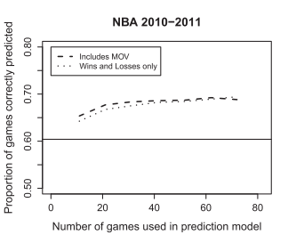

However, we see a pretty significant difference when implementing an info metric based off of a Monte-Carlo simulation from the predicted probabilties rather than the simple greater than 0.5 rule used in the paper. Next steps are to fit a similar quadratic curve as is what’s seen in the paper to see how it would compare to those.